# Generic Page - Massively by HTML5 UP

### Fargelegg observasjoner ved å bruke fargekartet

For å fargelegge punkter ved hjelp av et fargekart må vi erstatte `plot()` med `scatter()`:

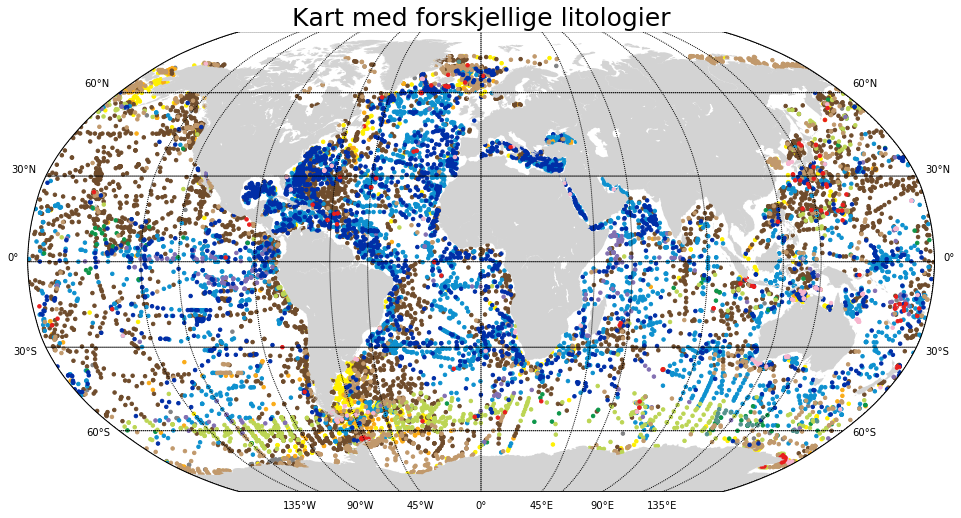

```python
#Definerer en variabel ved navn 'fig'. Her setter vi den lik plt.figure, dette får å opprette figuren og sette figurstørrelsen.
fig = plt.figure(figsize=(14,7))

#Definerer en variabel ved navn 'ax_map'. Her setter vi den lik fig.add_axes, med dette oppretter vi akser på figuren.
ax_map = fig.add_axes([0, 0, 0.9, 1.0])


#Definerer en variabel som jeg kaller for 'map_obs_col'. Dette lagrer et objekt av typen basemap i seg.
#Projection er hvilken kartprojeksjon vi vil plotte i. lon_0 og lat_0 er hvilke midtpunkter vi vil bruke.
#Resolution er oppløsningen til projektet. Denne er satt til lav('l'). Setter ax = ax_map, dette for å legge til aksene på figuren.
map_obs_col = Basemap(projection = 'robin', lon_0 = 0.0, lat_0 = 0.0, resolution = 'l', ax = ax_map)

#Her henter jeg inn basemap projektet jeg lagde og kalte for 'map_obs_col'.
#Fyller kontinentene inn med lysegrå farge og setter innsjøfarge til hvit.
map_obs_col.fillcontinents(color='lightgray',lake_color='w')

#Legger til tittel på kartet.
plt.title('Kart med forskjellige litologier', fontsize = 25)


#Her henter jeg inn basemap projektet jeg lagde.
#Deretter sier jeg at den projekteringen skal ha breddegrader fra -90 til 90 grader og at de skal vises ved siden av figuren.
map_obs_col.drawparallels(np.arange(-90.,120.,30.))
map_obs_col.drawparallels(np.arange(-90., 91., 30.), labels = [True, True, False, False])

#Her henter jeg inn basemap projektet jeg lagde.
#Deretter sier jeg at den projekteringen skal ha lengdegrader fra -180 til 180 grader og at de skal vises ved siden av figuren.
map_obs_col.drawmeridians(np.arange(0.,420.,60.))
map_obs_col.drawmeridians(np.arange(-180., 181., 45.), labels = [False, False, False, True])


#Her defineres det en variabel ved navn sc. Denne representerer basemap projeksjonen vi har. Fargelegger med cmap og bruker scatter ved denne.
#Denne tar inputs i form av lon_obs og lat_obs. Plotter de riktige borreprøvene og konverterer fargen til borreprøvene til litologien.
sc = map_obs_col.scatter(lon_obs, lat_obs, s = 12, marker = 'o', latlon = True, c = lith_obs, cmap = cpt_convert)
```

Sedimenttypene/litologiene er kodet på følgende måte:

1. Gravel and coarser
2. Sand
3. Silt
4. Clay
5. Calcareous ooze
6. Radiolarian ooze
7. Diatom ooze
8. Sponge spicules
9. Mixed calcareous/siliceous ooze
10. Shells and coral fragments
11. Ash and volcanic sand/gravel
12. Siliceous mud
13. Fine-grained calcareous sediment

Fra supplementet til Dutkiewicz et al. (2015):

**Gravel**: unconsolidated sediments coarser than sand; includes gravel, shelly gravel, sandy gravel, muddy gravel, pebbles, cobbles, diamicton, erratics, rock fragments, loose conglomerate, ice-rafted exotics, and till.

**Sand**: unconsolidated sediment dominated by sand-sized grains; includes quartz sand, detrital sand, shelly sand, glauconitic sand, clastic sand, silty sand, muddy sand, bioclastic sand, clayey sand, and clayey shelly sand.

**Silt**: unconsolidated sediment dominated by silt-sized grains; includes diatomaceous silt, clayey silt, sandy silt, calcareous silt, muddy silt, lutaceous silt, and shelly sandy silt.

**Clay**: unconsolidated sediment dominated by a clay-sized fraction and characterized by low carbonate and low biogenic content; includes sediments variously described as lutite, red clay, brown clay, zeolitic clay, zeolitic red clay, hemipelagic clay, pelagic clay, lutaceous clay, biosiliceous clay, radiolarian clay, diatomaceous clay, foraminiferal clay, radiolarian clay, foram lutite, silty clay, palagonitic clay, ashy clay and manganese lutite.

**Diatom ooze**: unconsolidated sediment containing > 30% diatom skeletons, in which diatoms are the dominant biogenic component; includes sediments variously described as diatom clay, clayey diatom ooze, diatomite, diatom mud, muddy diatom ooze, diatom clay ooze, diatom silty clay, radiolarian diatom ooze, and diatom marl.

**Radiolarian ooze**: unconsolidated sediment containing > 30% radiolarian skeletons, in which radiolarians are the dominant biogenic component; includes radiolarite.

**Sponge spicules**: unconsolidated sediments containing > 30% sponge spicules; includes spiculite.

**Calcareous ooze**: unconsolidated sediment containing > 30% calcareous skeletons (foraminifera, pterapods, coccoliths); includes sediments described as chalk if biogenic content is > 30%, calcareous marly ooze, foraminiferal marly ooze, foraminiferal chalk, chalk ooze, clayey nanno ooze, foraminiferal sand, foraminiferal marl and calcilutite if foraminifera > 30%.

**Mixed calcareous-siliceous ooze**: unconsolidated sediment containing > 30% of approximately equal portions of calcareous and siliceous microfossils. Proportions of these are often not specified in original reports or logs and sediment is simply classified as calcareous-siliceous ooze. Biogenic material includes foraminifera, nannofossils, discoasters, pteropods, diatoms, radiolarians and sponge spicules.

**Shells and coral fragments**: unconsolidated sediment dominated by biogenic fragments that are not oozes; includes shell hash, coral fragments, bryozoan fragments, reef sand, skeletal debris, coral hash, calcareous sand with minor terrigeous content, Halimeda fragments, coral hash, reef debris, limestone fragments, shells and mollusc fragments.

**Transitional calcareous sediments**: unconsolidated calcareous sediment containing < 30% identifiable biogenic components; includes marl, foraminiferal marl, radiolarian marl, calcareous clay, calcareous mud, calcilutite, nanno clay, foraminiferal clay/lutite, chalk if biogenic content is < 30%, mixtures of calcareous and siliceous clays, mixtures of terrigenous and calcareous clay.

**Transitional siliceous sediments**: unconsolidated siliceous sediment containing no or low amounts of carbonate including sediments described as mud, terrigenous mud, sandy mud, silty mud, sandy clay, sandy lutite, clayey mud and diatom mud (diatoms < 30% of sediment; if diatom mud contains > 30% diatoms, it is classified as diatom ooze).

**Volcaniclastics**: any unconsolidated sediment in which volcaniclastic grains are dominant irrespective of grain-size; includes ash, clayey ash, lapilli, glass, volcanic sand, volcanic mud, volcanic gravel, volcanic breccia, vitric silt, tuff, palagonite, tephra, silty tephra and volcanogenic detritus.

### Kart med tegnforklaring

Nå som vi vet hvordan de forskjellige litologiene er kodet, kan vi legge en tegnforklaring på kartet vårt.

```python
sediment_types = [
    'Gravel and coarser',
    'Sand',
    'Silt',
    'Clay',
    'Calcareous ooze',
    'Radiolarian ooze',
    'Diatom ooze',
    'Sponge spicules',
    'Mixed calcareous/siliceous ooze',
    'Shells and coral fragments',
    'Ash and volcanic sand/gravel',
    'Siliceous mud',
    'Fine-grained calcareous sediment']
```

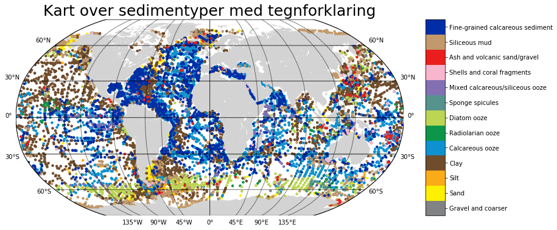

```python
#Definerer en variabel ved navn 'fig'. Her setter vi den lik plt.figure, dette får å opprette figuren og sette figurstørrelsen.
fig = plt.figure(figsize=(14,7))



#Definerer en variabel ved navn 'ax_map'. Her setter vi den lik fig.add_axes, med dette oppretter vi akser på figuren.
#Reduserer bredden for å gjøre plass til tegnforklaring.
ax_map = fig.add_axes([0, 0, 0.7, 1.0])

#Definerer en variabel som jeg kaller for 'map_obs_col'. Dette lagrer et objekt av typen basemap i seg.
#Projection er hvilken kartprojeksjon vi vil plotte i. lon_0 og lat_0 er hvilke midtpunkter vi vil bruke.
#Resolution er oppløsningen til projektet. Denne er satt til lav('l'). Setter ax = ax_map, dette for å legge til aksene på figuren.
map_obs_col = Basemap(projection = 'robin', lon_0 = 0.0, lat_0 = 0.0, resolution = 'l', ax = ax_map)

#Her henter jeg inn basemap projektet jeg lagde og kalte for 'map_obs_col'.
#Fyller kontinentene inn med lysegrå farge og setter innsjøfarge til hvit.
map_obs_col.fillcontinents(color='lightgray',lake_color='w')

#Her defineres det en variabel ved navn sc. Denne representerer basemap projeksjonen vi har. Fargelegger med cmap og bruker scatter ved denne.
#Denne tar inputs i form av lon_obs og lat_obs. Plotter de riktige borreprøvene og konverterer fargen til borreprøvene til litologien.
sc = map_obs_col.scatter(lon_obs, lat_obs, s = 12, marker = 'o', latlon = True, c = lith_obs, cmap = cpt_convert)

#Her henter jeg inn basemap projektet jeg lagde.
#Deretter sier jeg at den projekteringen skal ha breddegrader fra -90 til 90 grader og at de skal vises ved siden av figuren.
map_obs_col.drawparallels(np.arange(-90.,120.,30.))
map_obs_col.drawparallels(np.arange(-90., 91., 30.), labels = [True, True, False, False])

#Her henter jeg inn basemap projektet jeg lagde.
#Deretter sier jeg at den projekteringen skal ha lengdegrader fra -180 til 180 grader og at de skal vises ved siden av figuren.
map_obs_col.drawmeridians(np.arange(0.,420.,60.))
map_obs_col.drawmeridians(np.arange(-180., 181., 45.), labels = [False, False, False, True])

#Legger til tittel på kartet.
plt.title('Kart over sedimentyper med tegnforklaring', fontsize = 25)


#Definerer legenden.
bounds = np.linspace(0.5, 13.5, 14)
norm = mpl.colors.BoundaryNorm(bounds, cpt_convert.N)

#Definerer en ny variabel ved navn 'cbar'. Denne skal representere tegnforklaringen vår. Denne lages i basemap projektet 'map_obs_col'
cbar = map_obs_col.colorbar(sc, cmap = cpt_convert, norm = norm,
        spacing = 'proportional', ticks = bounds-.5, boundaries = bounds,
        format = '%s',location = 'right', pad = 0.5)

#Setter tekst forklaring til lik sedimenttypene som er definert i listen 'sediment_types = []'
cbar.set_ticklabels(sediment_types)
```